# Bike Trips Dataset Exploration

## by Rubén Triviño

We will use a dataset from [Lyft](https://www.lyft.com/bikes/bay-wheels/system-data) of bike trips and explore possible relationships between the day of the week and hour of the day when they start and usage trends.

### What is the structure of your dataset?

The data structures includes anonimous bike rides containing:

- Trip duration (seconds).
- Start datetime.
- Finish datetime.
- Station ID where the ride starts from.
- Station name where the ride starts from.
- Latitude of the station where the ride starts from.
- Longitude of the station where the ride starts from.
- Station ID where the ride ends.
- Station name where the ride ends.
- Latitude of the station where the ride ends.
- Longitude of the station where the ride ends.
- Bike ID
- User type (Subscriber or Customer)

### Our features of interest

For the porpuse of this study we are keen on the **start datetime** of the ride. Which **day of the week** has the most number of rides? Is there certain **hour of the day** that has a spike on rentals? Is there any difference in bike usage between **user types**? Then, in order to answer these questions we will use these main features of the dataset:

- Start Time (hour of the day, day of the week)
- User Type

## Univariate Exploration

### What hour of the day has more starting rides?

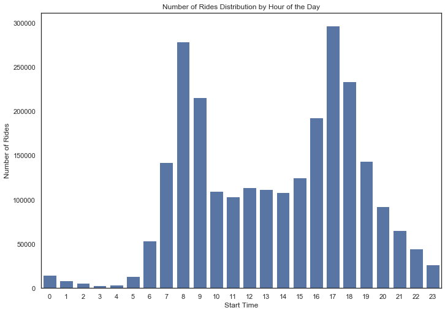

```python
color_palette = sb.color_palette()[0]
plt.figure(figsize=[ 11.69, 8.27])
sb.countplot(data=trip_data, x="start_time_hour", color=color_palette);
plt.title("Number of Rides Distribution by Hour of the Day");
plt.ylabel("Number of Rides");
plt.xlabel("Start Time");
```

We observe a bimodal distribution on the number of rides started by hour of the day. The two pikes that we find may be related to the hours of going to work or getting off it.

### Is there any difference on bike usage depending on the day of the week?

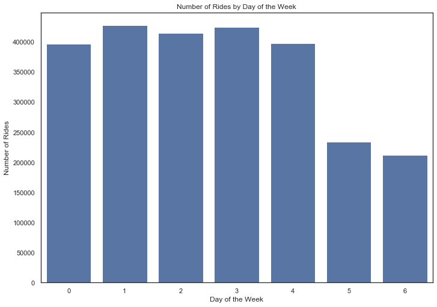

```python
plt.figure(figsize=[ 11.69, 8.27])
sb.countplot(data=trip_data, x="start_time_day_of_week", color=color_palette);
plt.title("Number of Rides by Day of the Week");
plt.ylabel("Number of Rides");
plt.xlabel("Day of the Week");
```

As we may see at the graph, it seems to be a consistently difference on the number of rides if they day is a weekday or it is from weekend. However, the days within the same group present similar number of rides. This relationship may have an impact on other features too so we will engineer a feature where we will say if it is weekday or weekend day.

### How is user type distribution relative to the bike usage?

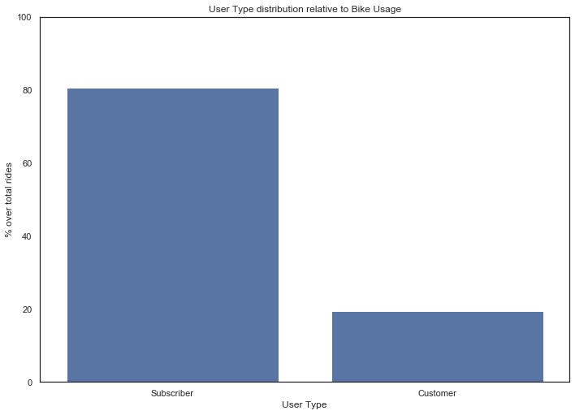

```python
# Calculate user type share
user_types = ["Subscriber", "Customer"]
total_trips = trip_data["user_type"].value_counts()/trip_data.shape[0] * 100
total_trips = total_trips.reset_index();
total_trips.rename(columns={"user_type": "distribution", "index": "user_type"}, inplace=True)

plt.figure(figsize=[ 11.69, 8.27])
sb.barplot(data = total_trips, x="user_type", y="distribution", color=color_palette, order=user_types);
plt.title("User Type distribution relative to Bike Usage");
plt.ylabel("% over total rides");
plt.xlabel("User Type");
plt.ylim(0,100);
```

Since we do not have unique identifiers for users we cannot know user type distribution. However, we are able to see user type distribution relative to the number of rides that each one takes. Therefore, we may see that the number of rides are from Subscriber users mainly. However, we do not know how is the duration of the rides regarding to the user type. So, what type of user would we like the most in terms of ride duration (potentially more money from renting the bike)? Do they have different usage profiles?

Given the previous findings we are going to distinguish between weekdays and weekends in the explorations.

### What about feature distribution?

As we have seen, bike usage distribution seems to be bimodal during weekdays. However, we also noticed that there is a sustancial difference between weekdays and weekends that will require further exploration.

## Bivariate Exploration

In this section we will explore the relationship between features such as:

- Is there any difference between user types on the time when they start the trips?
- How is the bike starting hour shape different from weekdays to weekend?

### Bike usage by User Type

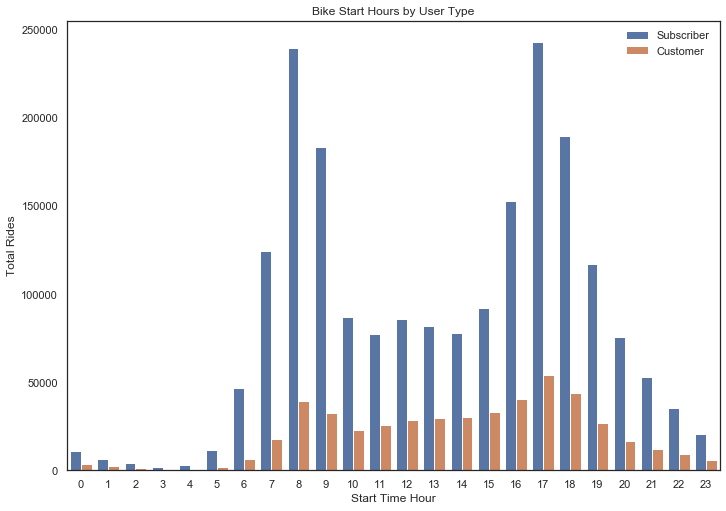

```python
plt.figure(figsize=[ 11.69, 8.27])
sb.countplot(data=trip_data, x="start_time_hour", hue="user_type");
legend = plt.legend(user_types);
plt.title("Bike Start Hours by User Type");
plt.ylabel("Total Rides");
plt.xlabel("Start Time Hour");
legend.get_frame().set_color('white');
```

Even though both users present similar shapes Customer Type seems to have a flatter bimodal distribution.

## How is the bike usage during weekdays and weekends?

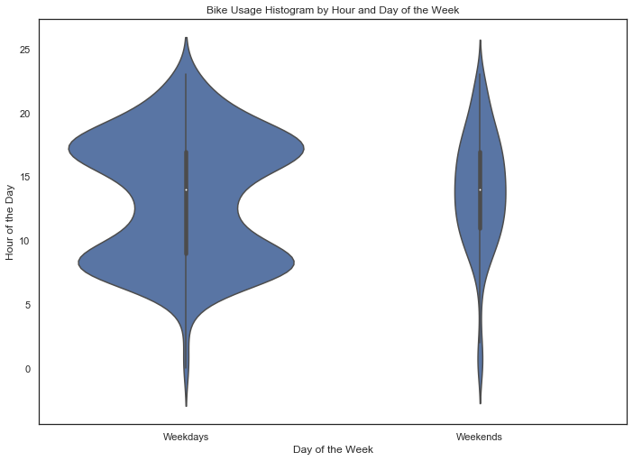

```python
plt.figure(figsize=[ 11.69, 8.27])
sb.violinplot(data=trip_data, y="start_time_hour", x="day_type",bw=.3, scale="count", color=color_palette);
plt.title("Bike Usage Histogram by Hour and Day of the Week");
plt.ylabel("Hour of the Day");
plt.xlabel("Day of the Week");
plt.xticks([0, 1], ["Weekdays", "Weekends"]);
```

As we can see in the above graph, bike usage distribution along hours of the day and type of day of the week, it present a very different shape. While bike usage during weekdays shows a bimodal distribution, during weekends we observe a normal distribution if we neglect the starting hours of the day.

### About some relationhips observed

We observed that they shape of bike usage is strongly linked to the day of the week. While weekdays present a big difference from weekends, days within the same group shows a very similar distribution.

## Multivariate Exploration

We have seen some relationships between trip starting times, bike usage by day of the week or user type distribution. But, what about start time by user type and day of the week or what about how these shapes varies from one station to another?

### Bike usage by day and user type

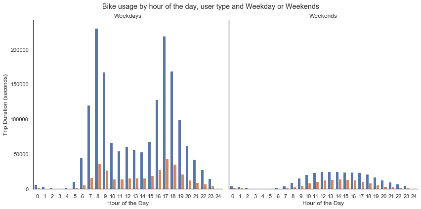

```python
# Define function to show different bar colors by user type in FacetGrid
def countplot(x, hue, **kwargs):
    sb.countplot(x=x, hue=hue, **kwargs)

g = sb.FacetGrid(trip_data, col="day_type", height=6);
g.map(countplot, "start_time_hour", "user_type", hue_order=user_types, order=np.arange(0,25,1), palette=sb.color_palette());
g.set_titles("{col_name}s");
g.set_ylabels("Trip Duration (seconds)");
g.set_xlabels("Hour of the Day");
g.fig.subplots_adjust(top=0.9);
g.fig.suptitle('Bike usage by hour of the day, user type and Weekday or Weekends');
```

As we may observe, user type does not have an impact on the time of day the trips are taken off but on the volumen of bike trips.

### Bike usage shapes by day type and top ten stations by name

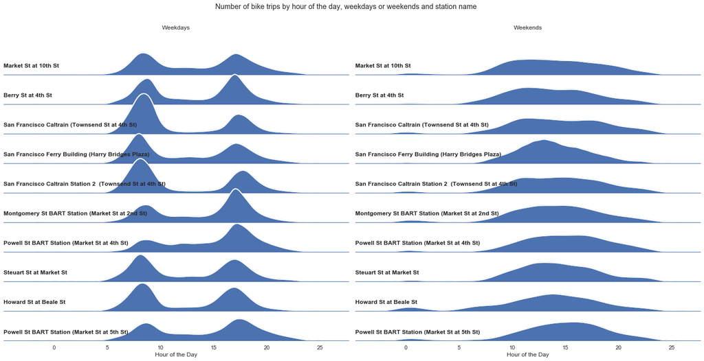

```python
# Generate graphs
import math
stations_order = trip_data["start_station_name"].value_counts()[:10].index;
sb.set(style="white", rc={"axes.facecolor": (0, 0, 0, 0)});
res = trip_data["start_time_hour"].values;
g = sb.FacetGrid(data = trip_data, row="start_station_name", col="day_type", row_order=stations_order, aspect=10, height=1);
g.map(sb.kdeplot, "start_time_hour", clip_on=False, shade=True, alpha=1, lw=1.5);
g.map(sb.kdeplot, "start_time_hour", clip_on=False, color="w", lw=2);
g.map(plt.axhline, y=0, lw=1, clip_on=False);
# Configure axis and labels
axes = g.axes.flatten()
index = 0;
for ax in axes:
    ax.text(0, .2, stations_order[math.floor(index/2)], fontweight="bold",
            ha="left", va="center", transform=ax.transAxes)
    if index==0:
        ax.set_title("Weekdays");
    elif index==1:
        ax.set_title("Weekends");
    else:
        ax.set_title("");
    index+=1
g.fig.subplots_adjust(hspace=-.30);
# Remove axes details that don't play well with overlap
g.set(yticks=[]);
g.despine(bottom=True, left=True);
g.set_xlabels("Hour of the Day");
g.fig.subplots_adjust(top=0.9);
g.fig.suptitle("Number of bike trips by hour of the day, weekdays or weekends and station name");
```

Last graph shows that every station present similar shapes; bimodal on weekdays and normal on weekends. However, they also show particularities in size, distance between pikes, horizontal shifts or even little areas with residual trips.

### Final Conclusions

Surprisingly, the two types of user have similar shapes on the different days of the week. The only difference resides in the volume of trips that each type during the day. However, we noticed that there is a great difference in bike usage between weekdays and weekends.

By comparing the busiest stations, we have seen that they have very similar usage profiles. Between stations there are only small variations in volume, time differences or small isolated areas with residual bicycle use.